# Access_to_your_own_reference_datasets

## How to access my own data with CliMAF (and the C-ESM-EP): creating a CliMAF project from scratch

### This page shows you how to create your own CliMAF project to acces your own data tree, either for your own simulations or your own observations

### We will use the ref_climatos and ref_ts projects to illustrate how to do it.

### The ref_climatos project provides access to a data tree of pre-calculated climatologies. Access to those files thus does not involve a smart selection of the period (typically proposed by CliMAF.

### The ref_ts project provides access to reference datasets evolving with time (time series). For those datasets, we will be interested by this smart period selection mechanism and we will see how to use it.

# Import CliMAF

```python
from climaf.api import *
```

```
Climaf version = 1.0.3_CESMEP
Cache directory set to : /prodigfs/ipslfs/dods/jservon/climafcache (use $CLIMAF_CACHE if set)
error    : 'defining cnco : command ${operator} is not executable'
warning  : Redefining CliMAF script ccdfmean_profile_box
Available macros read from ~/.climaf.macros are : []
```

# Example of how to declare a new MY_REFs CliMAF project

```python
# -- Start with the path/filename pattern.
# -- Include the keywords
pattern='/ccc/store/cont003/thredds/alekseee/MY_REFs/${product}/${variable}_${product}_${frequency}_${resolution}.nc'

# -- Declare that your new project takes the following arguments/keywords
cproject('MY_REFs','frequency','product','resolution')
# -- Finalize the project with dataloc
dataloc(project='MY_REFs', organization='generic', url=pattern)

# -- Add an alias for MY_REFs: if I want to use 'alk', CliMAF will replace 'alk' with 'Alkalini'
#    when trying to get my data; if it doesn't find a file with 'Alkalini', it will try by replacing 'Alkalini'
#    with filenameVar, here 'TALK'
calias('MY_REFs', 'alk', 'Alkalini', filenameVar='TALK')

# -- Specify a default value for 'period' for project 'MY_REFs' (and also for 'resolution')
cdef('period', 'fx', project='MY_REFs')
cdef('resolution', 'r360x180xl31', project='MY_REFs')

# -- Example of an alias that applies a scale and an offset
calias('IGCM_OUT', 'alk', 'Alkalini', scale=1./86400., offset=273.15, filenameVar='ptrc_T')
```

## Finally, try to access your data...

```python
my_dat = ds(project='MY_REFs', variable='alk', product='GLODAP')

# -- See the details of your request with summary(): keywords used and files found
summary(my_dat)
```

## Apply a CliMAF operator to check that your file is supported

```python
ANM = clim_average(my_dat, 'ANM')
cfile(ANM)
```

## And try to make a plot

```python
my_plot = plot(ANM)

# -- iplot is a function that does the cfile on my_plot, and display the result interactively in the notebook
iplot(my_plot)
```

[output not shown]

# You will find many examples of how to create your project in ${CLIMAF}/climaf/projects

# Here is another example with the ref_climatos and ref_ts projects

## We start with ref_climatos

```python
# -- We start with a typical path/filename in the 'climatos' data tree:
# /data/jservon/Evaluation/ReferenceDatasets/climatos/
#  ocn/mo/tos/UKMETOFFICE-HadISST-v1-1/ac/tos_pcmdi-metrics_Omon_UKMETOFFICE-HadISST-v1-1_198002-200501-clim.nc
# -- The principle is to insert the standard keywords and optional keywords of your choice
#    that you will need to identify your files from the ds() CliMAF data access interface

# -- As a start, we identify if we are working at TGCC or Ciclad to specify the root path
#    to the data tree
#   For this, we use the site settings variables:
from climaf.site_settings import onCiclad, atTGCC

root=None
if onCiclad:
    root="/data/jservon/Evaluation/ReferenceDatasets/"
if atTGCC:
    root="/ccc/work/cont003/igcmg/igcmg/IGCM/ReferenceDatasets/"

# -- Then, we take the path/filename pattern and insert the keywords.
# -- Standard keywords: variable, frequency, period, simulation
# -- Specific keywords: product, clim_period
#    We use 'product' to specify the name of the reference (ERAI, HadISST...)
#    Note on clim_period: for the climatologies, the period indicated on the files is the
#    period over which the climatology has been computed. It is this meaningless to
#    use the keyword period here, because we won't use the smart period selection
#    mechanism of CliMAF. This is why we rather introduce 'clim_period'
#    that is a simple character string (no period selection associated with it)
pattern=root+"climatos/*/${frequency}/${variable}/${product}/ac/${variable}_*${frequency}_${product}_*${clim_period}-clim.nc"

# -- Then, we use cproject to declare that the project 'ref_climatos' takes the following
#    arguments, and specify a separator;
#    ensemble=['product'] means that we specify that CliMAF will be able to build an ensemble
#    using eds() on the keyword 'product'
cproject('ref_climatos', 'frequency', 'product', 'clim_period', ensemble=['product'],separator='%')

# -- Now, we define aliases for the frequencies;
#    In CliMAF, we encourage to use plain english, explicit names for the vocabulary
#    (variable names, frequency names...)
cfreqs('ref_climatos', {'monthly':'mo' , 'daily':'day' , 'seasonal':'mo', 'annual_cycle':'mo', 'yearly':'yr'})

# -- Definition of a set of default values for the project ref_climatos
cdef('variable'    , '*'            , project='ref_climatos')
cdef('frequency'   , 'annual_cycle' , project='ref_climatos')
cdef('product'     , '*'            , project='ref_climatos')
cdef('clim_period' , '*'            , project='ref_climatos')
cdef('simulation'  , 'refproduct'   , project='ref_climatos')
# - because simulation is mandatory, we specify a default value 'refproduct'
cdef('period'      , 'fx'           , project='ref_climatos')
# -> period='fx' means that the fields we are looking at are fixed fields, in the sense
#    that they don't have a calendar

# -- Finalize the project with dataloc
dataloc(project='ref_climatos', organization='generic', url=pattern)
```

```
warning  : Redefining project ref_climatos
```

```
<climaf.dataloc.dataloc instance at 0x7efc8c8b65a8>
```

## We now test that the project is well defined by trying to access the data with ds()

```python
test = ds(project='ref_climatos', product='UKMETOFFICE-HadISST-v1-1', variable='tos')

summary(test)
```

```
warning  : Cannot yet filter files re. time using only file content. TBD
```

```
/data/jservon/Evaluation/ReferenceDatasets/climatos/ocn/mo/tos/UKMETOFFICE-HadISST-v1-1/ac/tos_pcmdi-metrics_Omon_UKMETOFFICE-HadISST-v1-1_198002-200501-clim.nc
```

```
{'clim_period': '*',
 'domain': 'global',
 'frequency': 'annual_cycle',
 'period': fx,
 'product': 'UKMETOFFICE-HadISST-v1-1',
 'project': 'ref_climatos',
 'simulation': 'refproduct',
 'variable': 'tos'}
```

## Do a plot to test that your files are actually correctly handled by the CliMAF operators (i.e. the cdo operators and ncl plot script)

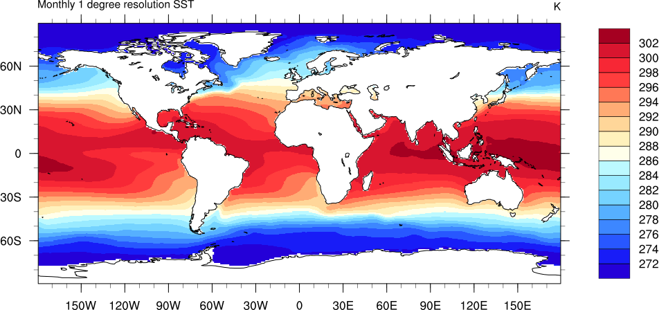

```python
test_plot = plot( clim_average(test, 'ANM') )

iplot(test_plot)
```

## Let's carry on now with ref_ts

## Here, we will declare a project that makes use of the smart period selection of CliMAF: incorporate YYYYMM-YYYYMM in the pattern

```python
# -- As for ref_climatos (and all the projects you want to add), we start with
#    the path/filename pattern:
# -> /data/jservon/Evaluation/ReferenceDatasets/ts/atm/mo/uas/uas_Amon_ERAInterim_reanalysis_197901-201112.nc
#    To use the smart period selection, we incorporate:
#       - YYYY to identify the year in the file (insert two YYYY strings in the pattern
#         to specify the starting year and ending year of the period)
#       - MM for the months
#       - DD for the days
#       -> typical possible values: YYYY, YYYY-YYYY, YYYYMM_YYYYMM, YYYYMMDD-YYYYMMDD
pattern=root+"ts/*/${frequency}/${variable}/${variable}_*mon_${product}*_YYYYMM-YYYYMM.nc"
#pattern=root+"ts/*/${frequency}/${variable}/${variable}_*${frequency}_${product}*_YYYYMM-YYYYMM.nc"


# -- Associate 'ref_ts' with its keywords
cproject('ref_ts', 'frequency', 'product', separator='%')

# -- Add some frequency aliases
cfreqs('ref_ts', {'monthly':'mo' , 'daily':'day', 'yearly':'yr' })

# -- and some default values
cdef('variable'    , '*'            , project='ref_ts')
cdef('frequency'   , 'monthly'      , project='ref_ts')
cdef('product'     , '*'            , project='ref_ts')
cdef('simulation'  , 'refproduct'   , project='ref_ts')
cdef('period'      , '1980-2005'    , project='ref_ts')

# -- Finalize with dataloc
dataloc(project='ref_ts', organization='generic', url=pattern)
```

```
warning  : Redefining project ref_ts
```

```
<climaf.dataloc.dataloc instance at 0x7efc8c584878>
```

## Then test the newly created ref_ts project with a data access try:

```python
test = ds(project='ref_ts', product='ERAInterim', variable='uas')

summary(test)
```

```
/data/jservon/Evaluation/ReferenceDatasets/ts/atm/mo/uas/uas_Amon_ERAInterim_reanalysis_197901-201112.nc
```

```
{'domain': 'global',
 'frequency': 'monthly',
 'period': 1980-2005,
 'product': 'ERAInterim',
 'project': 'ref_ts',
 'simulation': 'refproduct',
 'variable': 'uas'}
```

## And test the files by plotting a climatology

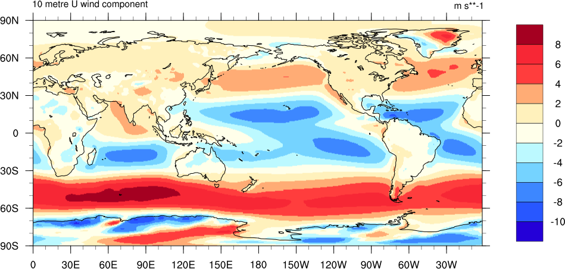

```python
test_plot = plot( clim_average(test, 'ANM') )

iplot(test_plot)
```